# HW3

Author

Michelle Hernandez

```r
setwd('/Users/michellehernandez/Desktop/DataScience/HW3')

library(data.table)
library(ggplot2)
library(tidytext)
library(readr)
library(dplyr)
library(forcats)
```

```r
dat <- read.csv("/Users/michellehernandez/Desktop/DataScience/HW3/pubmed.csv")
```

```r
dat %>%
  count('term', sort = TRUE)
```

```
  "term"    n
1   term 3241
```

```r
# the categories found through this method are overlapping

unique(dat$term)
```

```
[1] "covid"           "meningitis"      "prostate cancer" "cystic fibrosis"
[5] "preeclampsia"
```

```r
length(unique(dat$term))
```

```
[1] 5
```

## Question 1

1. Tokenize the abstracts and count the number of each token. Do you see anything interesting? Does removing stop words change what tokens appear as the most frequent? What are the 5 most common tokens for each search term after removing stopwords?

```r
dat %>%
  unnest_tokens(words, abstract) %>%
  count(words) %>%
  top_n(20,n)
```

```
      words     n
1        19  7080
2         a  8245
3       and 19993
4       are  2833
5        as  3159
6    cancer  3999
7     covid  7275
8       for  5492
9        in 14653
10       is  5649
11       of 24760
12 patients  4674
13 prostate  3832
14     that  3226
15      the 28126
16     this  3158
17       to 10920
18      was  3315
19     were  3226
20     with  8038
```

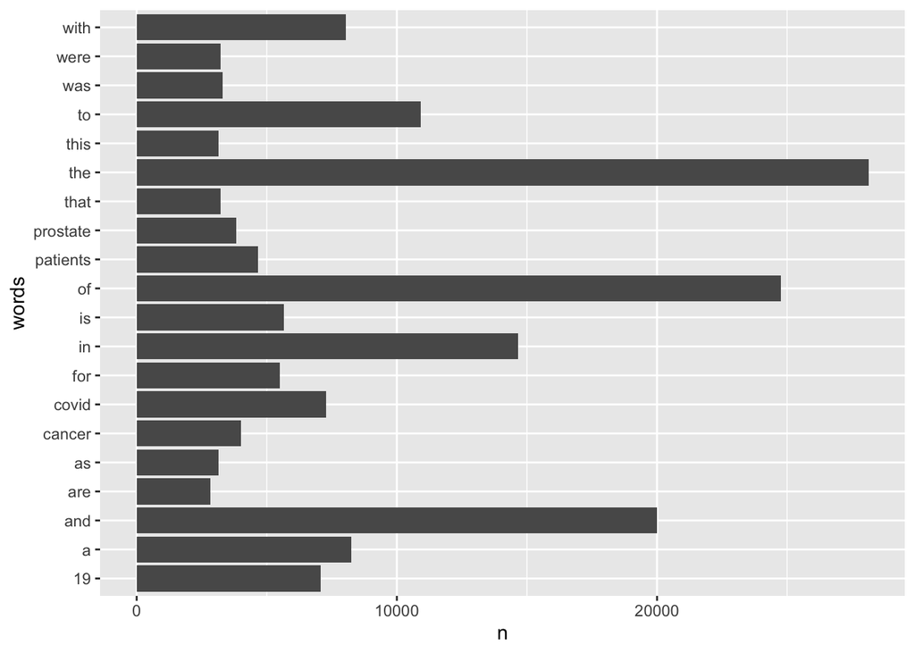

```r
dat %>%
  unnest_tokens(words, abstract) %>%
  count(words) %>%
  top_n(20,n) %>%
  ggplot(aes(n,words)) +
  geom_col()
```

Unsurprisingly the most common words are those that are commonly used in all sentences: *the, is, and, with, to…* etc*.* We can tell this is likely from medical or scientific documentation as some unique top words such as: *covid, cancer, patients, prostate*, that are specific scientific terminology.

#### **remove stop words**

```r
dat %>%
  unnest_tokens(words, abstract) %>%
  anti_join(stop_words, by=c("words" = "word")) %>%
  count(words, sort=TRUE) %>%
  filter(!grepl('[0-9]', words)) %>%
  top_n(20,n)
```

```
          words    n
1         covid 7275
2      patients 4674
3        cancer 3999
4      prostate 3832
5       disease 2574
6           pre 2165
7     eclampsia 2005
8  preeclampsia 1863
9     treatment 1841
10     clinical 1682
11         risk 1588
12        women 1327
13        study 1299
14      results 1281
15       severe 1063
16    diagnosis 1015
17    pregnancy 1011
18         data  945
19       health  922
20      studies  912
```

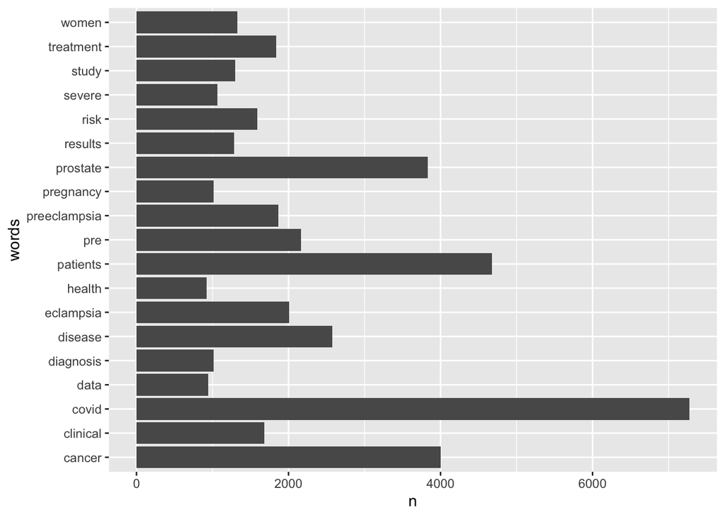

```r
dat %>%
  unnest_tokens(words, abstract) %>%
  anti_join(stop_words, by=c("words" = "word")) %>%
  count(words, sort=TRUE) %>%
  top_n(20,n) %>%
  filter(!grepl('[0-9]', words)) %>%
  ggplot(aes(n,words)) +
  geom_col()
```

**Find 5 most common words for each term after removing stop words**

```r
dat %>%
  unnest_tokens(words, abstract) %>%
  anti_join(stop_words, by = c("words" = "word")) %>%
  group_by(term) %>%
  count(words, sort = TRUE) %>%
  filter(!grepl('[0-9]', words)) %>%
  arrange(term, desc(n)) %>%
  group_by(term) %>%
  slice(1:5)
```

```
# A tibble: 25 × 3
# Groups:   term [5]
   term            words           n
   <chr>           <chr>       <int>
 1 covid           covid        7275
 2 covid           patients     2293
 3 covid           disease       943
 4 covid           pandemic      800
 5 covid           coronavirus   647
 6 cystic fibrosis fibrosis      867
 7 cystic fibrosis cystic        862
 8 cystic fibrosis cf            625
 9 cystic fibrosis patients      586
10 cystic fibrosis disease       400
# ℹ 15 more rows
```

Removing the stop words does change the most common tokens appear most frequently. We can see from the output the top words for each term, after removing stop words, are unique words that relate to the search term. For each search term, the most common words include the search term themselves and words relating to the topic. For example, it is not surprising that for the search term ‘preeclampsia’, which is a medical condition that affects pregnant women, *women* and *pregnancy* are the most common words outside of the search term itself.

The top 5 words for the search term covid are: *covid, patients, disease, pandemic, coronavirus*

The top 5 words for the search term cystic fibrosis are: *fibrosis, cystic, cf, patients, disease*

The top 5 words for the search term meningitis are: *patients, meningitis, meningeal, csf, clinical*

The top 5 words for the search term preeclampsia are: *pre, ecplampsia, preeclampsia, women, pregnancy*

## Question 2

Tokenize the abstracts into bigrams. Find the 10 most common bigrams and visualize them with ggplot2.

```r
dat %>%
  unnest_ngrams(ngram2, abstract, n = 2) %>%
  count(ngram2, sort=TRUE) %>%
  top_n(10,n)
```

```
            ngram2    n
1         covid 19 6969
2           of the 3883
3           in the 3418
4  prostate cancer 3222
5    pre eclampsia 1854
6    patients with 1587
7         of covid 1519
8          and the 1154
9           to the 1061
10     of prostate  870
```

[figure not shown]

```r
dat %>%
  unnest_ngrams(ngram2, abstract, n = 2) %>%
  count(ngram2, sort=TRUE) %>%
  top_n(20,n)%>%
  ggplot(aes(x = fct_reorder(ngram2, n), y = n)) +
  geom_col() +
  labs(title = "Top 10 Bigrams in Abstracts", x = "Bigram", y = "Frequency") +
  coord_flip() +
  theme_minimal()
```

## Question 3

Calculate the TF-IDF value for each word-search term combination (here you want the search term to be the “document”). What are the 5 tokens from each search term with the highest TF-IDF value? How are the results different from the answers you got in question 1?

```r
# dat %>%
#   unnest_tokens(abstract, abstract) %>%
#   count(abstract, term) %>%
#   bind_tf_idf(abstract, term, n) %>%
#   arrange(desc(tf_idf))
```

```r
dat %>%
  unnest_tokens(abstract, abstract) %>%
  anti_join(stop_words, by = c("abstract" = "word")) %>%
  group_by(term) %>%
  count(abstract, term) %>%
  bind_tf_idf(abstract, term, n) %>%
  filter(!grepl('[0-9]', term)) %>%
  arrange(term, desc(tf_idf)) %>%
  group_by(term) %>%
  slice(1:5)
```

```
# A tibble: 25 × 6
# Groups:   term [5]
   term            abstract        n      tf   idf  tf_idf
   <chr>           <chr>       <int>   <dbl> <dbl>   <dbl>
 1 covid           covid        7275 0.0647  1.61  0.104
 2 covid           pandemic      800 0.00711 1.61  0.0114
 3 covid           coronavirus   647 0.00575 1.61  0.00926
 4 covid           sars          372 0.00331 1.61  0.00532
 5 covid           cov           334 0.00297 1.61  0.00478
 6 cystic fibrosis cf            625 0.0234  0.916 0.0215
 7 cystic fibrosis fibrosis      867 0.0325  0.511 0.0166
 8 cystic fibrosis cystic        862 0.0323  0.511 0.0165
 9 cystic fibrosis cftr           86 0.00322 1.61  0.00518
10 cystic fibrosis sweat          83 0.00311 1.61  0.00500
# ℹ 15 more rows
```

For the search term cystic fibrosis has the same top 3 words however the order here is different. In question 1 the top 3 in order were: *fibrosis, cystic, cf*. Using the TF-IDF score the order changes to: *cf, fibrosis, cystic*. New words introduced for the search term cystic fibrosis, are, in order: *cftr* and *sweat*

For the search term meningitis the order for the top 3 words changed from: *patients*, *meningitis, meningeal* to *meningitis, meningeal, pachymeningitis. csf* remains the 4th most common word and *meninges* replaced *clinical* as the 5th most common word.

Similarly for the preeclampsia search term the order of the top few words from #1 has changed order and a few new words were added. Common, generic words *pre* and *women* are not included here.

We can see here that there are unique words that did not come up as top words before. For example, sweat is one of the top words for cystic fibrosis. Apparently excess sweating is in fact a symptom for those with cystic fibrosis (https://www.mayoclinic.org/diseases-conditions/cystic-fibrosis/symptoms-causes/syc-20353700). Similarly for the search preeclampsia we see more complex words relating to the disease, ie *gestational* and *maternal.* The TF-IDF analysis revealed words that are distinct to each search term and helped shed light on the relevance of these words in the context of their respective search terms compared to question 1.